# Tugas Praktikum Pertemuan 2

Rahmandani

2025-08-31

```r
data_btc1 = read.csv("C:/Users/PC/Downloads/btc_historical_price.csv")

data_btc= data_btc1[829:1656,]
View(data_btc)
dim(data_btc)
```

```
## [1] 828   2
```

```r
library("forecast")
```

```r
library("graphics")
library("TTR")
library("TSA")
library("ggplot2")
library("dplyr")
library("lubridate")
library("zoo")
library("stats")
```

```r
data_btc.ts= ts(data_btc$price)
summary(data_btc.ts)
```

```
##    Min. 1st Qu.  Median    Mean 3rd Qu.    Max.
##   66.34  199.35  315.98  368.75  542.35 1147.25
```

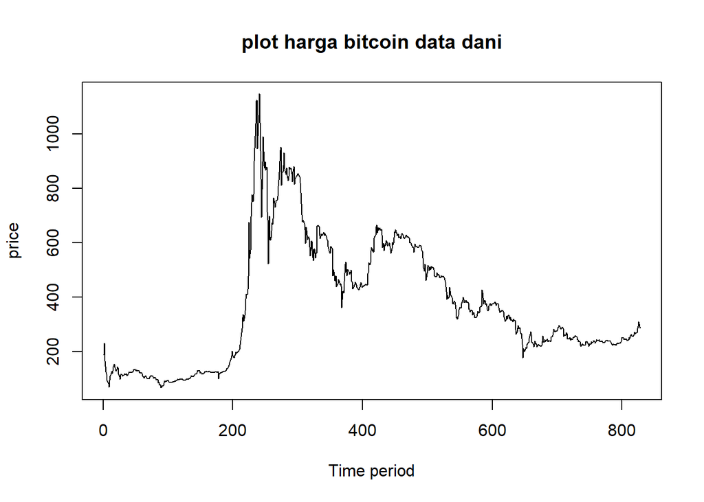

```r
ts.plot(data_btc.ts, xlab="Time period", ylab="price", main = "plot harga bitcoin data dani")
```

```r
jumlah_data = nrow(data_btc)

n_data_train = floor(0.8 * jumlah_data)

train_data = data_btc[1:n_data_train, ]
test_data  = data_btc[(n_data_train+1):jumlah_data, ]

train_data.ts = ts(train_data$price)
test_data.ts = ts(test_data$price)

train_data$date <- as.Date(train_data$date, format = "%m/%d/%Y")
test_data$date  <- as.Date(test_data$date,  format = "%m/%d/%Y")
```

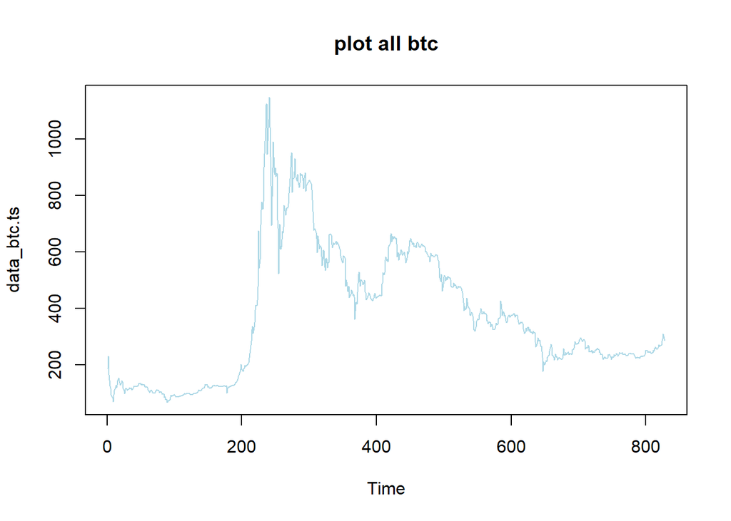

```r
plot(data_btc.ts, col="light blue", main = "plot all btc")
```

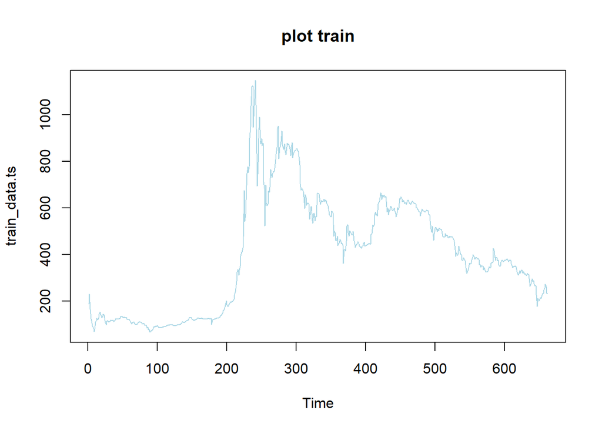

```r
plot(train_data.ts, col= "light blue",main="plot train")
```

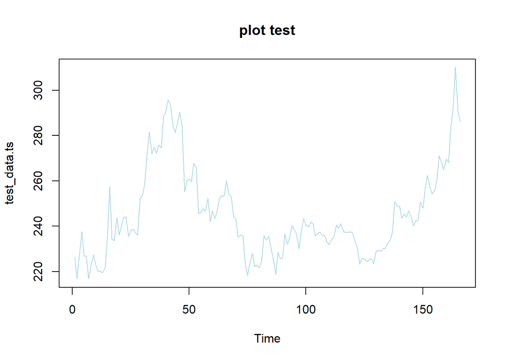

```r
plot(test_data.ts, col = "light blue", main = "plot test")
```

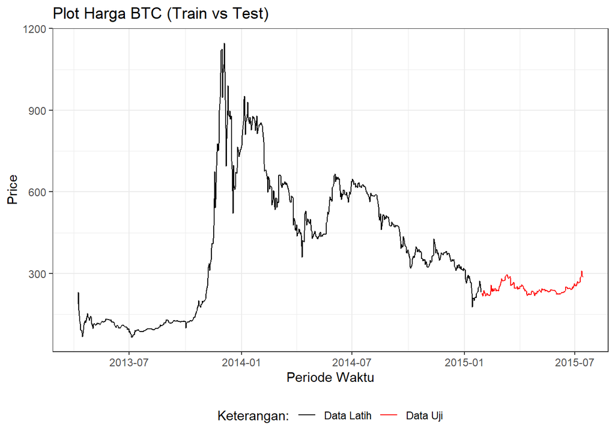

```r
ggplot() +
  geom_line(data = train_data, aes(x = date, y = price, col = "Data Latih")) +
  geom_line(data = test_data, aes(x = date, y = price, col = "Data Uji")) +
  labs(title = "Plot Harga BTC (Train vs Test)",
       x = "Periode Waktu", y = "Price", color = "Legend") +
  scale_colour_manual(name = "Keterangan:",
                      breaks = c("Data Latih", "Data Uji"),
                      values = c("Data Latih" = "black", "Data Uji" = "red")) +
  theme_bw() +
  theme(legend.position = "bottom",
        plot.caption = element_text(hjust = 0.5, size = 12))
```

```r
data.sma = SMA(train_data.ts, n=15)
data.sma
```

```
## Time Series:
## Start = 1
## End = 662
## Frequency = 1
##   [1]        NA        NA        NA        NA        NA        NA        NA
##   [8]        NA        NA        NA        NA        NA        NA        NA
##  [15] 123.46115 120.52615 115.47281 113.92015 114.72015 115.45349 118.21645
##  [22] 121.81644 125.60583 128.80745 129.68612 128.95879 128.58679 127.87775
##  [29] 127.41442 126.22776 124.20943 121.44936 119.84869 118.43136 117.55269
##  [36] 116.45504 114.28171 112.61459 112.73659 113.88659 115.56065 116.20065
##  [43] 116.60332 117.31265 118.25931 119.13265 120.48605 121.43845 122.62911
##  [50] 123.62578 124.36047 125.75047 126.72240 127.42941 127.81607 127.76867
##  [57] 127.65115 127.60982 127.54382 127.22181 126.20181 124.52131 122.41807
##  [64] 120.60807 119.22340 117.87513 115.98839 114.06846 112.13412 110.17412
##  [71] 108.80412 107.91164 107.03504 106.32771 105.69638 105.50971 105.51022
```

[output cut: 84 more lines]

```r
data.ramal<-c(NA,data.sma)
data.ramal
```

```
##   [1]        NA        NA        NA        NA        NA        NA        NA
##   [8]        NA        NA        NA        NA        NA        NA        NA
##  [15]        NA 123.46115 120.52615 115.47281 113.92015 114.72015 115.45349
##  [22] 118.21645 121.81644 125.60583 128.80745 129.68612 128.95879 128.58679
##  [29] 127.87775 127.41442 126.22776 124.20943 121.44936 119.84869 118.43136
##  [36] 117.55269 116.45504 114.28171 112.61459 112.73659 113.88659 115.56065
##  [43] 116.20065 116.60332 117.31265 118.25931 119.13265 120.48605 121.43845
##  [50] 122.62911 123.62578 124.36047 125.75047 126.72240 127.42941 127.81607
##  [57] 127.76867 127.65115 127.60982 127.54382 127.22181 126.20181 124.52131
##  [64] 122.41807 120.60807 119.22340 117.87513 115.98839 114.06846 112.13412
##  [71] 110.17412 108.80412 107.91164 107.03504 106.32771 105.69638 105.50971
##  [78] 105.51022 105.62039 105.41901 105.08568 104.61641 103.99714 103.66374
##  [85] 103.51107 102.49153 101.53861  99.50795  97.47022  94.47355  91.63055
##  [92]  89.25091  87.02824  85.17057  83.91629  83.06429  82.17950  81.96142
##  [99]  81.65291  81.36157  81.90388  82.09630  82.66561  83.20511  84.49361
```

[output cut: 80 more lines]

```r
data.gab = cbind(
  aktual=c(data_btc.ts),
  pemulusan=c(data.sma,rep(NA,166)),
  ramalan=c(data.ramal,rep(data.ramal[length(data.ramal)],165)))

data.gab
```

```
##           aktual pemulusan   ramalan
##   [1,]  187.5000        NA        NA
##   [2,]  230.0000        NA        NA
##   [3,]  165.0000        NA        NA
##   [4,]  124.9000        NA        NA
##   [5,]  117.0000        NA        NA
##   [6,]   93.0000        NA        NA
##   [7,]   90.0000        NA        NA
##   [8,]   82.3860        NA        NA
##   [9,]   68.3557        NA        NA
##  [10,]   93.0700        NA        NA
##  [11,]  109.0100        NA        NA
##  [12,]  118.4800        NA        NA
##  [13,]  126.6155        NA        NA
##  [14,]  119.2000        NA        NA
```

[output cut: 814 more lines]

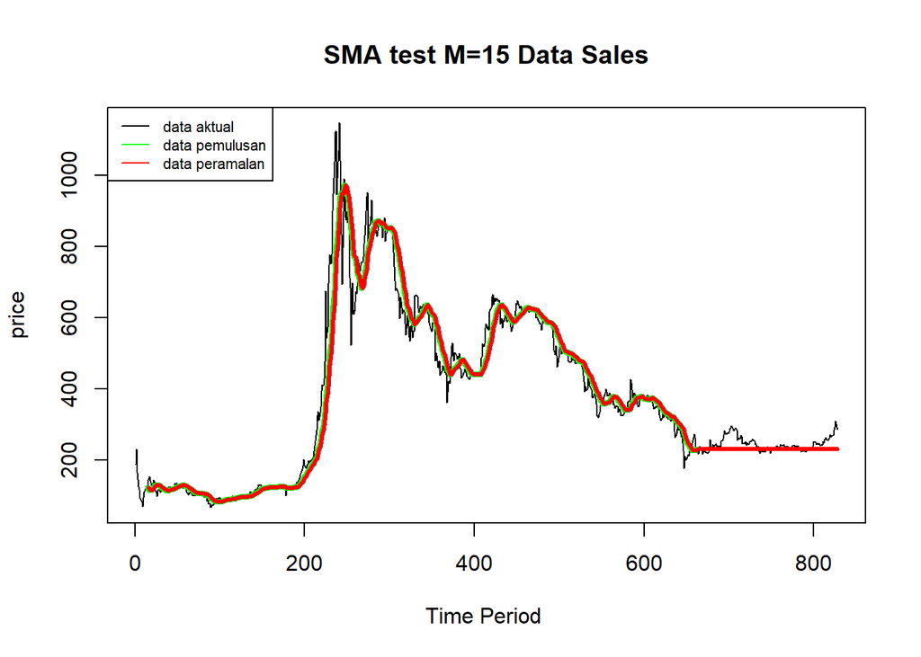

```r
ts.plot(data_btc.ts, xlab="Time Period ", ylab="price", main= "SMA test M=15 Data Sales")

lines(data.gab[,2],col="green",lwd=4)
lines(data.gab[,3],col="red",lwd=3)
legend("topleft",c("data aktual","data pemulusan","data peramalan"), lty=7, col=c("black","green","red"), cex=0.7)
```

```r
#Menghitung nilai keakuratan data latih
error_train.sma = train_data.ts-data.ramal[1:length(train_data.ts)]

SSE_train.sma = sum(error_train.sma[16:length(train_data.ts)]^2)
MSE_train.sma = mean(error_train.sma[16:length(train_data.ts)]^2)
MAPE_train.sma = mean(abs((error_train.sma[16:length(train_data.ts)]/train_data.ts[16:length(train_data.ts)])*100))

akurasi_train.sma = matrix(c(SSE_train.sma, MSE_train.sma, MAPE_train.sma))
row.names(akurasi_train.sma)= c("SSE", "MSE", "MAPE")
colnames(akurasi_train.sma)= c("Akurasi m = 15")
akurasi_train.sma
```

```
##      Akurasi m = 15
## SSE    3.262261e+06
## MSE    5.042134e+03
## MAPE   9.172620e+00
```

```r
#Menghitung nilai keakuratan data uji
error_test.sma = test_data.ts-data.gab[663:828,3]

SSE_test.sma = sum(error_test.sma^2)
MSE_test.sma = mean(error_test.sma^2)
MAPE_test.sma = mean(abs(((error_test.sma/test_data.ts)*100)))

akurasi_test.sma <- matrix(c(SSE_test.sma, MSE_test.sma, MAPE_test.sma))
row.names(akurasi_test.sma)<- c("SSE", "MSE", "MAPE")
colnames(akurasi_test.sma) <- c("Akurasi m = 15")
akurasi_test.sma
```

```
##      Akurasi m = 15
## SSE    1.018456e+05
## MSE    6.135276e+02
## MAPE   6.812123e+00
```

```r
dma <- SMA(data.sma, n = 15)
At <- 2*data.sma - dma
Bt <- 2/(15-1)*(data.sma - dma)
data.dma<- At+Bt
data.ramal2<- c(NA, data.dma)

t = 1:166
f = c()

for (i in t) {
  f[i] = At[length(At)] + Bt[length(Bt)]*(i)
}

data.gab2 <- cbind(aktual = c(data_btc.ts),
                   pemulusan1 = c(data.sma,rep(NA,166)),
                   pemulusan2 = c(dma, rep(NA,166)),
                   At = c(At, rep(NA,166)),
                   Bt = c(Bt,rep(NA,166)),
                   ramalan = c(data.ramal2, f[-1]))
View(data.gab2)
```

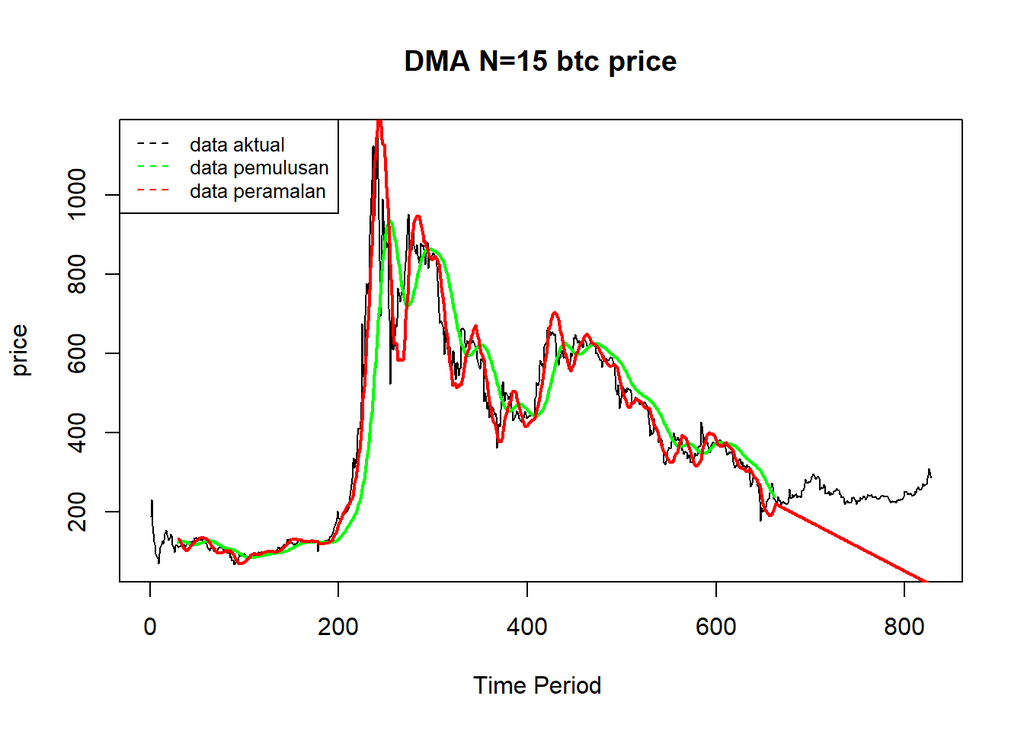

```r
ts.plot(data_btc.ts, xlab="Time Period ", ylab="price", main= "DMA N=15 btc price")

lines(data.gab2[,3],col="green",lwd=2)
lines(data.gab2[,6],col="red",lwd=2)
legend("topleft",c("data aktual","data pemulusan","data peramalan"), lty=8, col=c("black","green","red"), cex=0.8)
```

```r
#Menghitung nilai keakuratan data latih
error_train.dma = train_data.ts-data.ramal2[1:length(train_data.ts)]

SSE_train.dma = sum(error_train.dma[30:length(train_data.ts)]^2)
MSE_train.dma = mean(error_train.dma[30:length(train_data.ts)]^2)
MAPE_train.dma = mean(abs((error_train.dma[30:length(train_data.ts)]/train_data.ts[30:length(train_data.ts)])*100))

akurasi_train.dma <- matrix(c(SSE_train.dma, MSE_train.dma, MAPE_train.dma))
row.names(akurasi_train.dma)<- c("SSE", "MSE", "MAPE")
colnames(akurasi_train.dma) <- c("Akurasi m = 15")
akurasi_train.dma
```

```
##      Akurasi m = 15
## SSE    2.381478e+06
## MSE    3.762208e+03
## MAPE   7.898526e+00
```

```r
error_test.dma = test_data.ts-data.gab2[663:828,6]
SSE_test.dma = sum(error_test.dma^2)
MSE_test.dma = mean(error_test.dma^2)
MAPE_test.dma = mean(abs((error_test.dma/test_data.ts*100)))

akurasi_test.dma <- matrix(c(SSE_test.dma, MSE_test.dma, MAPE_test.dma))
row.names(akurasi_test.dma)<- c("SSE", "MSE", "MAPE")
colnames(akurasi_test.dma) <- c("Akurasi m = 15")
akurasi_test.dma
```

```
##      Akurasi m = 15
## SSE    3.375113e+06
## MSE    2.033201e+04
## MAPE   5.157002e+01
```

Hasil DMA kurang baik karena MAPE yang jauh lebih besar dari pada 10%

#COBA SMA dan DMA m = 7 (1 minggu)

```r
data.sma7 = SMA(train_data.ts, n=7)
data.ramal7 <- c(NA, data.sma7)
```

```r
# Gabungkan data untuk plot
data.gab7 = cbind(
  aktual = c(data_btc.ts),
  pemulusan = c(data.sma7, rep(NA, length(data_btc.ts) - length(data.sma7))),
  ramalan = c(data.ramal7, rep(data.ramal7[length(data.ramal7)], length(data_btc.ts) - length(data.ramal7)))
)
```

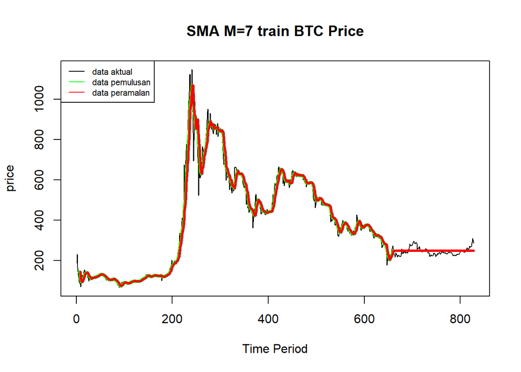

```r
# Plot SMA m=7
ts.plot(data_btc.ts, xlab="Time Period", ylab="price", main="SMA M=7 train BTC Price")
lines(data.gab7[,2], col="green", lwd=4)
lines(data.gab7[,3], col="red", lwd=3)
legend("topleft", c("data aktual","data pemulusan","data peramalan"),
       lty=7, col=c("black","green","red"), cex=0.7)
```

```r
# Akurasi SMA m=7

error_train.sma7 = train_data.ts - data.ramal7[1:length(train_data.ts)]

SSE_train.sma7 = sum(error_train.sma7[8:length(train_data.ts)]^2) # mulai dari m+1
MSE_train.sma7 = mean(error_train.sma7[8:length(train_data.ts)]^2)
MAPE_train.sma7 = mean(abs(error_train.sma7[8:length(train_data.ts)] / train_data.ts[8:length(train_data.ts)] * 100))

akurasi_train.sma7 = matrix(c(SSE_train.sma7, MSE_train.sma7, MAPE_train.sma7))
row.names(akurasi_train.sma7) = c("SSE","MSE","MAPE")
colnames(akurasi_train.sma7) = c("Akurasi train sma m = 7")
akurasi_train.sma7
```

```
##      Akurasi train sma m = 7
## SSE             1.489917e+06
## MSE             2.274683e+03
## MAPE            6.415937e+00
```

```r
# Akurasi data uji SMA m=7
error_test.sma7 = test_data.ts - data.gab7[(length(train_data.ts)+1):length(data_btc.ts), 3]

SSE_test.sma7 = sum(error_test.sma7^2)
MSE_test.sma7 = mean(error_test.sma7^2)
MAPE_test.sma7 = mean(abs(error_test.sma7 / test_data.ts * 100))

akurasi_test.sma7 = matrix(c(SSE_test.sma7, MSE_test.sma7, MAPE_test.sma7))
row.names(akurasi_test.sma7) = c("SSE","MSE","MAPE")
colnames(akurasi_test.sma7) = c("Akurasi test sma m = 7")
akurasi_test.sma7
```

```
##      Akurasi test sma m = 7
## SSE            64226.141760
## MSE              386.904468
## MAPE               6.520457
```

```r
# DMA dengan m = 7

dma7 <- SMA(data.sma7, n = 7)
At7 <- 2*data.sma7 - dma7
Bt7 <- 2/(7-1)*(data.sma7 - dma7)
data.dma7 <- At7 + Bt7
data.ramal2_7 <- c(NA, data.dma7)

t7 = 1:length(test_data.ts)
f7 = c()
for (i in t7) {
  f7[i] = At7[length(At7)] + Bt7[length(Bt7)]*i
}

data.gab2_7 <- cbind(
  aktual = c(data_btc.ts),
  pemulusan1 = c(data.sma7, rep(NA, length(test_data.ts))),
  pemulusan2 = c(dma7, rep(NA, length(test_data.ts))),
  At = c(At7, rep(NA, length(test_data.ts))),
  Bt = c(Bt7, rep(NA, length(test_data.ts))),
  ramalan = c(data.ramal2_7, f7[-1])
)
```

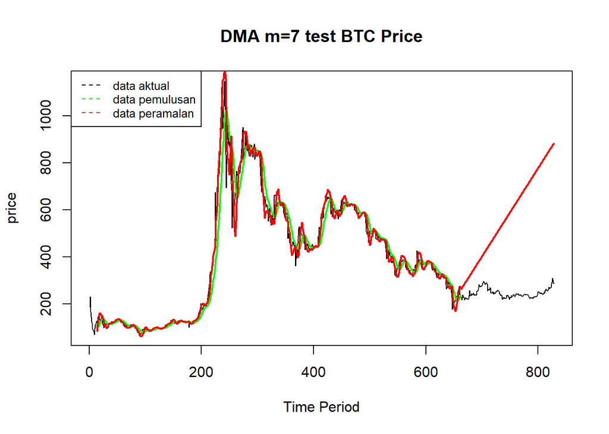

```r
# Plot DMA m=7
ts.plot(data_btc.ts, xlab="Time Period", ylab="price", main="DMA m=7 test BTC Price")
lines(data.gab2_7[,3], col="green", lwd=2)
lines(data.gab2_7[,6], col="red", lwd=2)
legend("topleft", c("data aktual","data pemulusan","data peramalan"),
       lty=8, col=c("black","green","red"), cex=0.8)
```

```r
# Akurasi DMA m=7

error_train.dma7 = train_data.ts - data.ramal2_7[1:length(train_data.ts)]

SSE_train.dma7 = sum(error_train.dma7[14:length(train_data.ts)]^2)
MSE_train.dma7 = mean(error_train.dma7[14:length(train_data.ts)]^2)
MAPE_train.dma7 = mean(abs(error_train.dma7[14:length(train_data.ts)] / train_data.ts[14:length(train_data.ts)] * 100))

akurasi_train.dma7 = matrix(c(SSE_train.dma7, MSE_train.dma7, MAPE_train.dma7))
row.names(akurasi_train.dma7) = c("SSE","MSE","MAPE")
colnames(akurasi_train.dma7) = c("Akurasi train dma m = 7")
akurasi_train.dma7
```

```
##      Akurasi train dma m = 7
## SSE             1.127540e+06
## MSE             1.737350e+03
## MAPE            5.555365e+00
```

```r
error_test.dma7 = test_data.ts - data.ramal2_7[1:length(test_data.ts)]

SSE_test.dma7 = sum(error_test.dma7[14:length(test_data.ts)]^2) # mulai dari 2*m
MSE_test.dma7 = mean(error_test.dma7[14:length(test_data.ts)]^2)
MAPE_test.dma7 = mean(abs(error_test.dma7[14:length(test_data.ts)] / test_data.ts[14:length(test_data.ts)] * 100))

akurasi_test.dma7 = matrix(c(SSE_test.dma7, MSE_test.dma7, MAPE_test.dma7))
row.names(akurasi_test.dma7) = c("SSE","MSE","MAPE")
colnames(akurasi_test.dma7) = c("Akurasi test dma m = 7")
akurasi_test.dma7
```

```
##      Akurasi test dma m = 7
## SSE            2.968653e+06
## MSE            1.940296e+04
## MAPE           5.584712e+01
```

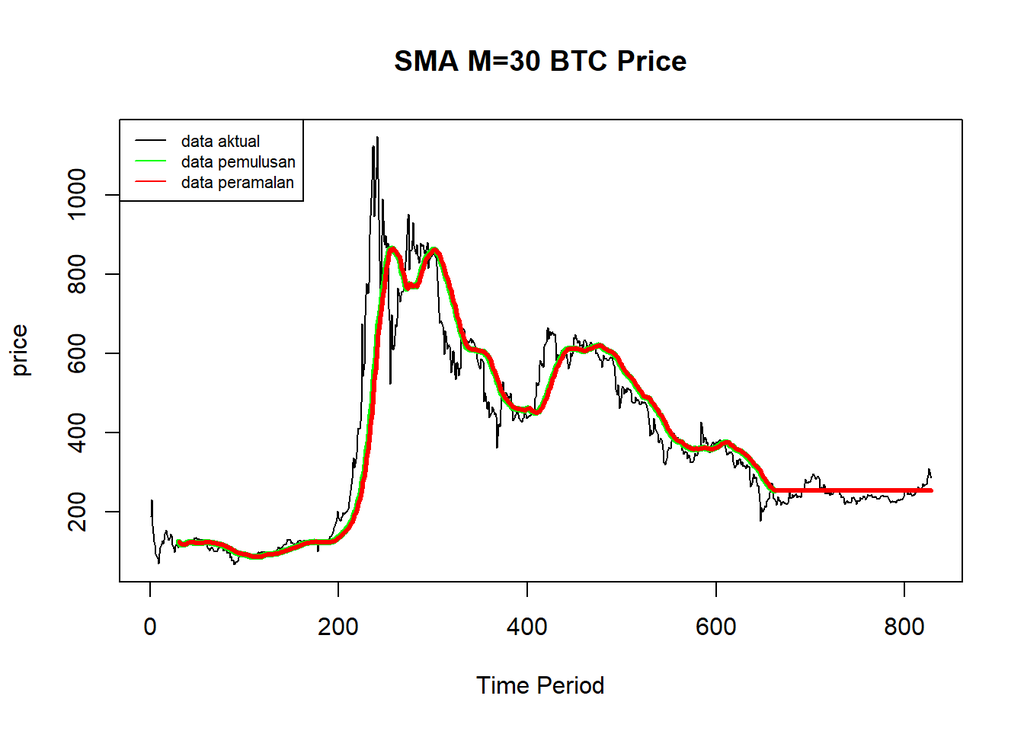

```r
# SMA m= 30

data.sma30 = SMA(train_data.ts, n=30)

data.ramal30= c(NA, data.sma30)


#plot
data.gab30 = cbind(
  aktual = c(data_btc.ts),
  pemulusan = c(data.sma30, rep(NA, length(data_btc.ts) - length(data.sma30))),
  ramalan = c(data.ramal30, rep(data.ramal30[length(data.ramal30)], length(data_btc.ts) - length(data.ramal30)))
)


# Plot SMA m=30
ts.plot(data_btc.ts, xlab="Time Period", ylab="price", main="SMA M=30 BTC Price")
lines(data.gab30[,2], col="green", lwd=4)
lines(data.gab30[,3], col="red", lwd=3)
legend("topleft", c("data aktual","data pemulusan","data peramalan"),
       lty=7, col=c("black","green","red"), cex=0.7)
```

```r
# Akurasi SMA m=  30
error_train.sma30 = train_data.ts - data.ramal30[1:length(train_data.ts)]

SSE_train.sma30 = sum(error_train.sma30[31:length(train_data.ts)]^2) # mulai dari m+1
MSE_train.sma30 = mean(error_train.sma30[31:length(train_data.ts)]^2)
MAPE_train.sma30 = mean(abs(error_train.sma30[31:length(train_data.ts)] / train_data.ts[31:length(train_data.ts)] * 100))

akurasi_train.sma30 = matrix(c(SSE_train.sma30, MSE_train.sma30, MAPE_train.sma30))
row.names(akurasi_train.sma30) = c("SSE","MSE","MAPE")
colnames(akurasi_train.sma30) = c("Akurasi sma train m = 30")
akurasi_train.sma30
```

```
##      Akurasi sma train m = 30
## SSE              6.770695e+06
## MSE              1.071313e+04
## MAPE             1.250307e+01
```

```r
# Akurasi data uji SMA m = 30
error_test.sma30 = test_data.ts - data.gab30[(length(train_data.ts)+1):length(data_btc.ts), 3]

SSE_test.sma30 = sum(error_test.sma30^2)
MSE_test.sma30 = mean(error_test.sma30^2)
MAPE_test.sma30 = mean(abs(error_test.sma30 / test_data.ts * 100))

akurasi_test.sma30 = matrix(c(SSE_test.sma30, MSE_test.sma30, MAPE_test.sma30))
row.names(akurasi_test.sma30) = c("SSE","MSE","MAPE")
colnames(akurasi_test.sma30) = c("Akurasi sma test m = 30")
akurasi_test.sma30
```

```
##      Akurasi sma test m = 30
## SSE             72039.730442
## MSE               433.974280
## MAPE                7.358278
```

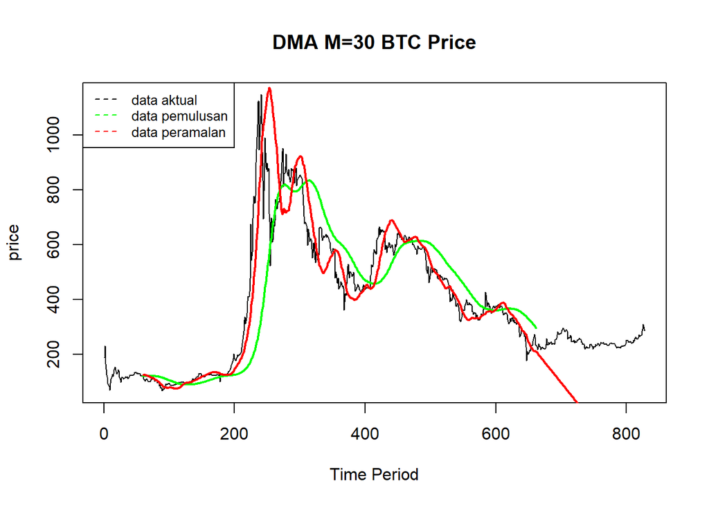

```r
# DMA m=30
dma30= SMA(data.sma30, n = 30)
At30 = 2*data.sma30 - dma30
Bt30 = 2/(30-1)*(data.sma30 - dma30)
data.dma30 <- At30 + Bt30
data.ramal2_30= c(NA, data.dma30)

t30 = 1:length(test_data.ts)
f30 = c()
for (i in t30) {
  f30[i] = At30[length(At30)] + Bt30[length(Bt30)]*i
}

data.gab2_30 = cbind(
  aktual = c(data_btc.ts),
  pemulusan1 = c(data.sma30, rep(NA, length(test_data.ts))),
  pemulusan2 = c(dma30, rep(NA, length(test_data.ts))),
  At = c(At30, rep(NA, length(test_data.ts))),
  Bt = c(Bt30, rep(NA, length(test_data.ts))),
  ramalan = c(data.ramal2_30, f30[-1])
)

# Plot DMA m=30
ts.plot(data_btc.ts, xlab="Time Period", ylab="price", main="DMA M=30 BTC Price")
lines(data.gab2_30[,3], col="green", lwd=2)
lines(data.gab2_30[,6], col="red", lwd=2)
legend("topleft", c("data aktual","data pemulusan","data peramalan"),
       lty=8, col=c("black","green","red"), cex=0.8)
```

```r
# Akurasi DMA m=30 train
error_train.dma30 = train_data.ts - data.ramal2_30[1:length(train_data.ts)]

SSE_train.dma30 = sum(error_train.dma30[61:length(train_data.ts)]^2)
MSE_train.dma30 = mean(error_train.dma30[61:length(train_data.ts)]^2)
MAPE_train.dma30 = mean(abs(error_train.dma30[61:length(train_data.ts)] / train_data.ts[61:length(train_data.ts)] * 100))

akurasi_train.dma30 = matrix(c(SSE_train.dma30, MSE_train.dma30, MAPE_train.dma30))
row.names(akurasi_train.dma30) = c("SSE","MSE","MAPE")
colnames(akurasi_train.dma30) = c("Akurasi dma train m = 30")
akurasi_train.dma30
```

```
##      Akurasi dma train m = 30
## SSE              6.087539e+06
## MSE              1.011219e+04
## MAPE             1.176141e+01
```

```r
# Akurasi DMA m=30 test
error_test.dma30 = test_data.ts - data.ramal2_30[1:length(test_data.ts)]

SSE_test.dma30 = sum(error_test.dma30[61:length(test_data.ts)]^2)
MSE_test.dma30 = mean(error_test.dma30[61:length(test_data.ts)]^2)
MAPE_test.dma30 = mean(abs(error_test.dma30[61:length(test_data.ts)] / test_data.ts[61:length(test_data.ts)] * 100))

akurasi_test.dma30 = matrix(c(SSE_test.dma30, MSE_test.dma30, MAPE_test.dma30))
row.names(akurasi_test.dma30) = c("SSE","MSE","MAPE")
colnames(akurasi_test.dma30) = c("Akurasi dma test m = 30")
akurasi_test.dma30
```

```
##      Akurasi dma test m = 30
## SSE             2.112727e+06
## MSE             1.993139e+04
## MAPE            5.819416e+01
```

#Kesimpulan SMA & DMA PAda kasus ini bisa diketahui bahwa semakin kecil M nya maka akan menghasilkan SSE MSE MAPE yang lebih baik namun terlalu sensitif dan banyak noisenya. Untuk pemilihan M untuk bitcoin ini efektif pada m = 7 menggunakan SMA karena cukup sesuai dengan harga / data bitcoin yang sangat volatile. Berdasarkan hasil SSE MSE MAPE antara SMA dan DMA, SMA mampu memberikan hasil yang jauh lebih baik. Selain dari ketiga indikator tadi, berdasarkan hasil visual plot uji, SMA dapat memberikan hasil yang lebih akurat pada kasus ini.

```r
#Mencoba SES & DES

n = nrow(data_btc)


n_train = floor(0.8 * n)


training = data_btc[1:n_train, ]
testing  = data_btc[(n_train+1):n, ]


train.ts = ts(training$price)
test.ts  = ts(testing$price)
```

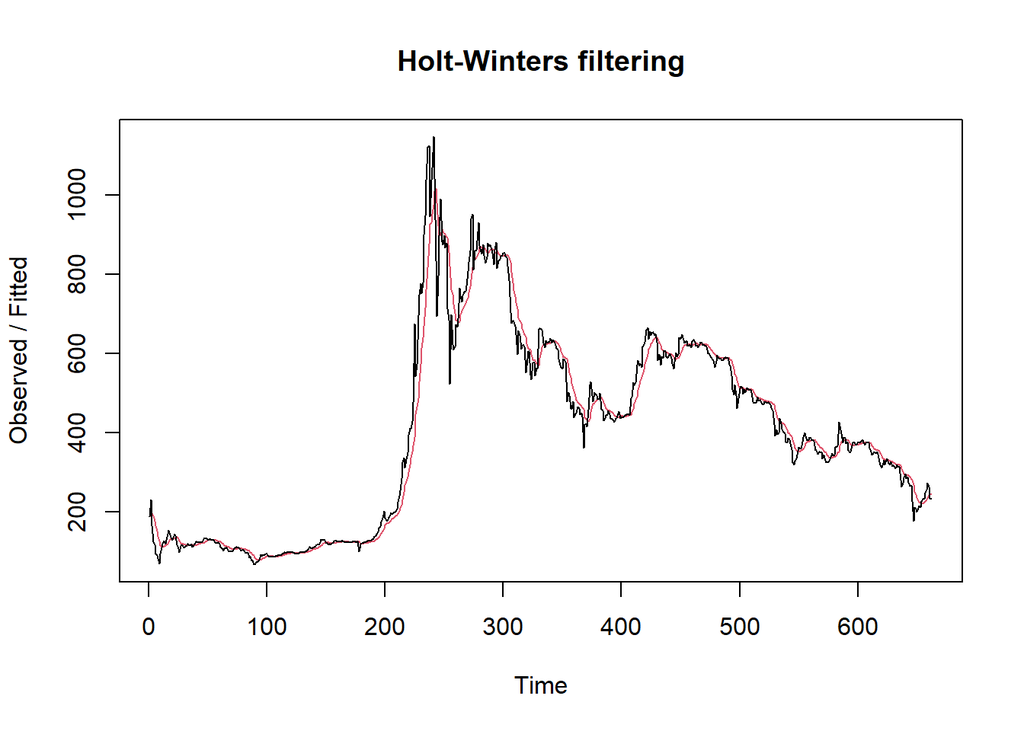

```r
#Fungsi holtwinter alpha 0.2
ses1<- HoltWinters(train.ts, gamma = FALSE, beta = FALSE, alpha = 0.2)
plot(ses1)
```

```r
ramalan1 = forecast(ses1, h= 166)
ramalan1
```

```
##     Point Forecast     Lo 80    Hi 80       Lo 95    Hi 95
## 663       241.3956 178.35012 304.4411 144.9758600 337.8153
## 664       241.3956 177.10157 305.6896 143.0663729 339.7248
## 665       241.3956 175.87681 306.9144 141.1932671 341.5979
## 666       241.3956 174.67453 308.1167 139.3545389 343.4366
## 667       241.3956 173.49354 309.2976 137.5483623 345.2428
## 668       241.3956 172.33274 310.4585 135.7730674 347.0181
## 669       241.3956 171.19112 311.6001 134.0271222 348.7641
## 670       241.3956 170.06778 312.7234 132.3091176 350.4821
## 671       241.3956 168.96186 313.8293 130.6177535 352.1734
## 672       241.3956 167.87257 314.9186 128.9518278 353.8394
## 673       241.3956 166.79918 315.9920 127.3102262 355.4810
## 674       241.3956 165.74102 317.0502 125.6919132 357.0993
## 675       241.3956 164.69746 318.0937 124.0959249 358.6953
## 676       241.3956 163.66791 319.1233 122.5213623 360.2698
```

[output cut: 152 more lines]

```r
# SES dengan alpha = 0.2
SSE1<-ses1$SSE
MSE1<-ses1$SSE/length(train.ts)
RMSE1<-sqrt(MSE1)

akurasi1 <- matrix(c(SSE1,MSE1,RMSE1))
row.names(akurasi1)<- c("SSE", "MSE", "RMSE")
colnames(akurasi1) <- c("Akurasi lamda=0.2")
akurasi1
```

```
##      Akurasi lamda=0.2
## SSE       1.597385e+06
## MSE       2.412968e+03
## RMSE      4.912197e+01
```

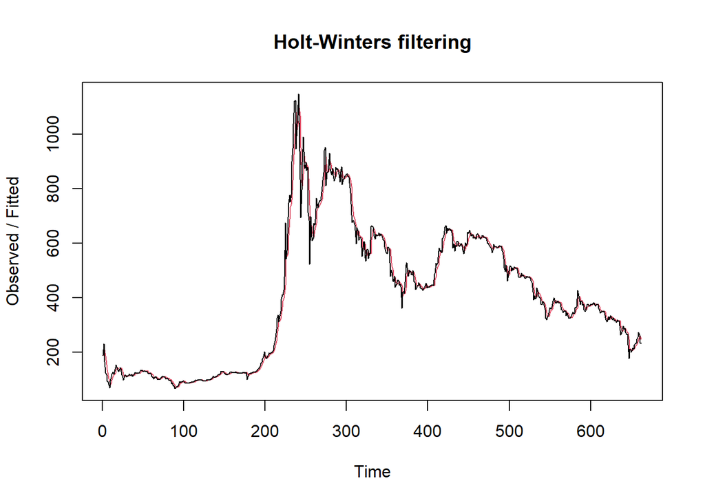

```r
#SES alpha 0.5
ses2<- HoltWinters(train.ts, gamma = FALSE, beta = FALSE, alpha = 0.5)
plot(ses2)
```

```r
ramalan2 = forecast(ses2, h= 166)
ramalan2
```

```
##     Point Forecast      Lo 80    Hi 80        Lo 95    Hi 95
## 663       239.6686 196.566977 282.7702  173.7503747 305.5868
## 664       239.6686 191.479524 287.8576  165.9697879 313.3673
## 665       239.6686 186.880116 292.4570  158.9355998 320.4015
## 666       239.6686 182.650523 296.6866  152.4669962 326.8701
## 667       239.6686 178.713715 300.6234  146.4461668 332.8910
## 668       239.6686 175.016183 304.3209  140.7912801 338.5458
## 669       239.6686 171.518971 307.8182  135.4427554 343.8944
## 670       239.6686 168.192668 311.1445  130.3556137 348.9815
## 671       239.6686 165.014425 314.3227  125.4949111 353.8422
## 672       239.6686 161.966073 317.3711  120.8328584 358.5043
## 673       239.6686 159.032878 320.3042  116.3469242 362.9902
## 674       239.6686 156.202699 323.1344  112.0185395 367.3186
## 675       239.6686 153.465390 325.8717  107.8321856 371.5049
## 676       239.6686 150.812366 328.5248  103.7747356 375.5624
```

[output cut: 152 more lines]

```r
SSE2<-ses2$SSE
MSE2<-ses2$SSE/length(train.ts)
RMSE2<-sqrt(MSE2)

akurasi2 <- matrix(c(SSE2,MSE2,RMSE2))
row.names(akurasi2)<- c("SSE", "MSE", "RMSE")
colnames(akurasi2) <- c("Akurasi lamda=0.5")
akurasi2
```

```
##      Akurasi lamda=0.5
## SSE       746565.42026
## MSE         1127.74233
## RMSE          33.58187
```

```r
# SES dengan alpha = 0.7
ses3<- HoltWinters(train.ts, gamma = FALSE, beta = FALSE, alpha = 0.7)
ses3
```

```
## Holt-Winters exponential smoothing without trend and without seasonal component.
##
## Call:
## HoltWinters(x = train.ts, alpha = 0.7, beta = FALSE, gamma = FALSE)
##
## Smoothing parameters:
##  alpha: 0.7
##  beta : FALSE
##  gamma: FALSE
##
## Coefficients:
##       [,1]
## a 235.3407
```

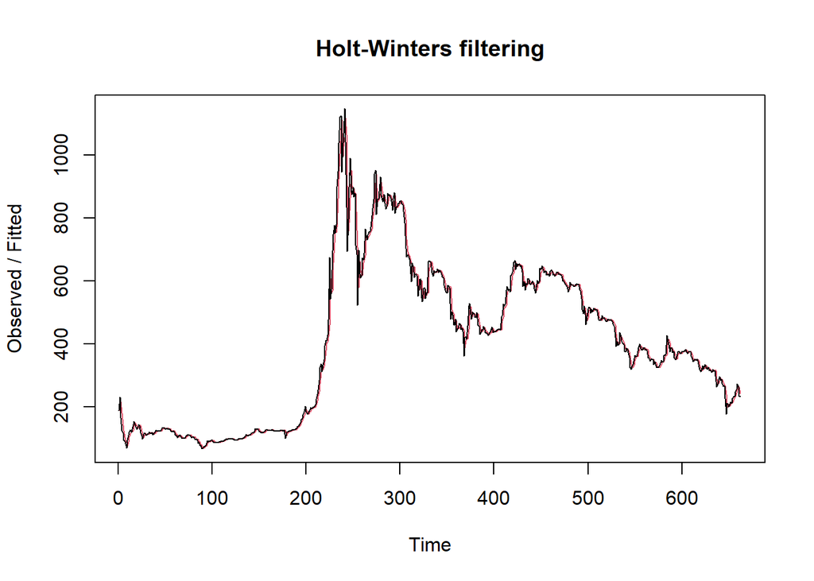

```r
plot(ses3)
```

```r
ramalan3 = forecast(ses3, h = 166)
ramalan3
```

```
##     Point Forecast        Lo 80    Hi 80       Lo 95    Hi 95
## 663       235.3407  195.6656906 275.0158  174.662984 296.0185
## 664       235.3407  186.9111684 283.7703  161.274097 309.4074
## 665       235.3407  179.5129935 291.1685  149.959565 320.7219
## 666       235.3407  172.9865006 297.6950  139.978156 330.7033
## 667       235.3407  167.0811980 303.6003  130.946775 339.7347
## 668       235.3407  161.6475993 309.0339  122.636803 348.0447
## 669       235.3407  156.5880073 314.0935  114.898824 355.7827
## 670       235.3407  151.8344119 318.8471  107.628828 363.0527
## 671       235.3407  147.3372130 323.3443  100.750956 369.9305
## 672       235.3407  143.0589179 327.6226   94.207868 376.4736
## 673       235.3407  138.9703679 331.7111   87.954970 382.7265
## 674       235.3407  135.0483547 335.6331   81.956768 388.7247
## 675       235.3407  131.2740475 339.4074   76.184464 394.4970
## 676       235.3407  127.6319175 343.0496   70.614307 400.0672
```

[output cut: 152 more lines]

```r
SSE3<-ses3$SSE
MSE3<-ses3$SSE/length(train.ts)
RMSE3<-sqrt(MSE3)

akurasi3 <- matrix(c(SSE3,MSE3,RMSE3))
row.names(akurasi3)<- c("SSE", "MSE", "RMSE")
colnames(akurasi3) <- c("Akurasi lamda=0.7")
akurasi3
```

```
##      Akurasi lamda=0.7
## SSE       632574.60236
## MSE          955.55076
## RMSE          30.91198
```

```r
#Mencari Mape
fitted3<-ramalan3$fitted
sisaan3<-ramalan3$residuals
head(sisaan3)
```

```
## Time Series:
## Start = 1
## End = 6
## Frequency = 1
## [1]        NA  42.50000 -52.25000 -55.77500 -24.63250 -31.38975
```

```r
resid3<-train_data$price-ramalan1$fitted
head(resid3)
```

```
## Time Series:
## Start = 1
## End = 6
## Frequency = 1
## [1]      NA  42.500 -31.000 -64.900 -59.820 -71.856
```

```r
MAPE.3 = sum(abs(sisaan3[2:length(train.ts)]/train.ts[2:length(train.ts)])*
               100)/length(train.ts)
MAPE.3
```

```
## [1] 3.895823
```

```r
akurasi.3 <- matrix(c(MAPE.3))
row.names(akurasi.3)<- c("MAPE")
colnames(akurasi.3) <- c("Akurasi lamda=0.7")
akurasi.3
```

```
##      Akurasi lamda=0.7
## MAPE          3.895823
```

```r
#SES dengan alpha = optimal
ses4<- HoltWinters(train.ts, gamma = FALSE, beta = FALSE,alpha = NULL)
ses4
```

```
## Holt-Winters exponential smoothing without trend and without seasonal component.
##
## Call:
## HoltWinters(x = train.ts, alpha = NULL, beta = FALSE, gamma = FALSE)
##
## Smoothing parameters:
##  alpha: 0.9999531
##  beta : FALSE
##  gamma: FALSE
##
## Coefficients:
##       [,1]
## a 232.4048
```

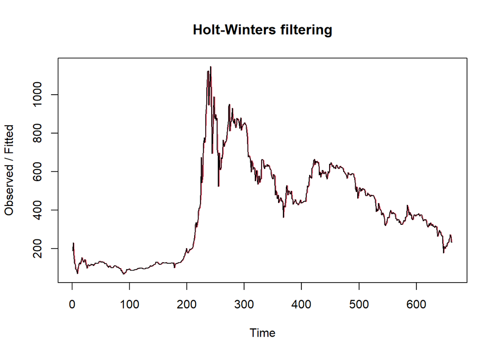

```r
plot(ses4)
```

```r
ramalan4 = forecast(ses4, h =166)
ramalan4
```

```
##     Point Forecast        Lo 80    Hi 80        Lo 95    Hi 95
## 663       232.4048  194.3015454 270.5081  174.1308809 290.6788
## 664       232.4048  178.5199073 286.2898  149.9949482 314.8147
## 665       232.4048  166.4100609 298.3996  131.4745363 333.3351
## 666       232.4048  156.2009309 308.6087  115.8610194 348.9487
## 667       232.4048  147.2064794 317.6032  102.1051929 362.7045
## 668       232.4048  139.0748581 325.7348   89.6689512 375.1407
## 669       232.4048  131.5970506 333.2126   78.2326316 386.5770
## 670       232.4048  124.6368704 340.1728   67.5879545 397.2217
## 671       232.4048  118.0997213 346.7100   57.5902478 407.2194
## 672       232.4048  111.9167284 352.8929   48.1341762 416.6755
## 673       232.4048  106.0358964 358.7738   39.1402198 425.6695
## 674       232.4048  100.4168301 364.3928   30.5465993 434.2631
## 675       232.4048   95.0274050 369.7823   22.3041851 442.5055
## 676       232.4048   89.8415751 374.9681   14.3731425 450.4365
```

[output cut: 152 more lines]

```r
SSE4<-ses4$SSE
MSE4<-ses4$SSE/length(train.ts)
RMSE4<-sqrt(MSE4)

akurasi4 <- matrix(c(SSE4,MSE4,RMSE4))
row.names(akurasi4)<- c("SSE", "MSE", "RMSE")
colnames(akurasi4) <- c("Akurasi lamda= optimal")
akurasi4
```

```
##      Akurasi lamda= optimal
## SSE            583443.81491
## MSE               881.33507
## RMSE               29.68729
```

```r
#SES dengan alpha = optimal
SSE4<-ses4$SSE
MSE4<-ses4$SSE/length(train.ts)
RMSE4<-sqrt(MSE4)

akurasi4 <- matrix(c(SSE4,MSE4,RMSE4))
row.names(akurasi4)<- c("SSE", "MSE", "RMSE")
colnames(akurasi4) <- c("Akurasi lamda= optimal")
akurasi4
```

```
##      Akurasi lamda= optimal
## SSE            583443.81491
## MSE               881.33507
## RMSE               29.68729
```

```r
#Akurasi data uji
#alpha 0.2
accuracy(ramalan1, test_data$price)
```

```
##                     ME     RMSE      MAE        MPE     MAPE      MASE
## Training set 0.4076823 49.15911 25.96916 -0.8343691 6.737531 1.7594568
## Test set     3.6215826 19.79614 14.66599  0.8952749 5.766947 0.9936469
##                   ACF1
## Training set 0.7966815
## Test set            NA
```

```r
#alpha0.5
accuracy(ramalan2, test_data$price)
```

```
##                     ME     RMSE      MAE       MPE     MAPE      MASE      ACF1
## Training set 0.1578474 33.60727 17.04153 -0.313939 4.373877 1.1545943 0.4684201
## Test set     5.3486127 20.18363 14.58863  1.604305 5.693723 0.9884059        NA
```

```r
#alpha 0.7
accuracy(ramalan3, test_data$price)
```

```
##                     ME     RMSE      MAE        MPE     MAPE     MASE      ACF1
## Training set 0.1033947 30.93536 15.46566 -0.2206387 3.901717 1.047826 0.2794223
## Test set     9.6764282 21.73487 15.15982  3.3810858 5.831180 1.027105        NA
```

```r
#alpha opt atau 0.99
accuracy(ramalan4, test_data$price)
```

```
##                       ME     RMSE     MAE        MPE     MAPE     MASE
## Training set  0.06793788 29.70974 14.7598 -0.1510174 3.642746 1.000003
## Test set     12.61233878 23.19143 16.4001  4.5864210 6.285795 1.111136
##                     ACF1
## Training set 0.007880331
## Test set              NA
```

#Hasil SES Berdasarkan hasil SES yang telah dilakukan, dapat diketahui saat pengujian model terhadap data train pada kasus ini semakin besar nilai alpha (makin dekat dengan 1), maka hasil ME RMSE MSE dan MAPE akan semakin bagus dibanding yang lain. Namun, saat telah mencoba dilakukan forecasting dengan test_data (data uji) alpha yang “optimal” tidak lagi memberikan hasil yang terbaik. Menurut saya, pada data uji hasil terbaik dihasilkan oleh alpha 0.2 dengan nilai ME RMSE yang cenderung lebih kecil dari pada yang lain dan MAPE sekitar 5.7%

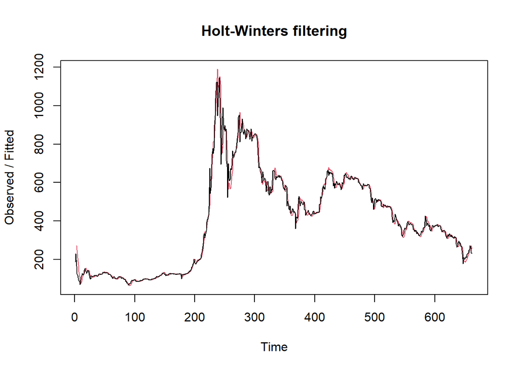

```r
#Mencoba DES

des.1<- HoltWinters(train_data.ts, gamma = FALSE, beta = 0.2, alpha = 0.5)
plot(des.1)
```

```r
ramalandes1<- forecast(des.1, h=166)
ramalandes1
```

```
##     Point Forecast        Lo 80     Hi 80        Lo 95     Hi 95
## 663       243.5912   199.968196  287.2142   176.875573  310.3068
## 664       243.5562   192.683509  294.4290   165.753115  321.3594
## 665       243.5213   184.187573  302.8550   152.778211  334.2643
## 666       243.4863   174.650370  312.3222   138.210827  348.7618
## 667       243.4513   164.206224  322.6965   122.256393  364.6463
## 668       243.4164   152.957797  333.8750   105.071916  381.7608
## 669       243.3814   140.983445  345.7794    86.777234  399.9856
## 670       243.3465   128.343774  358.3491    67.465034  419.2279
## 671       243.3115   115.086573  371.5364    47.208403  439.4146
## 672       243.2765   101.250319  385.3027    26.066188  460.4869
## 673       243.2416    86.866636  399.6165     4.086751  482.3964
## 674       243.2066    71.962003  414.4512   -18.689408  505.1026
## 675       243.1716    56.558977  429.7843   -42.227796  528.5711
## 676       243.1367    40.677058  445.5963   -66.498586  552.7719
```

[output cut: 152 more lines]

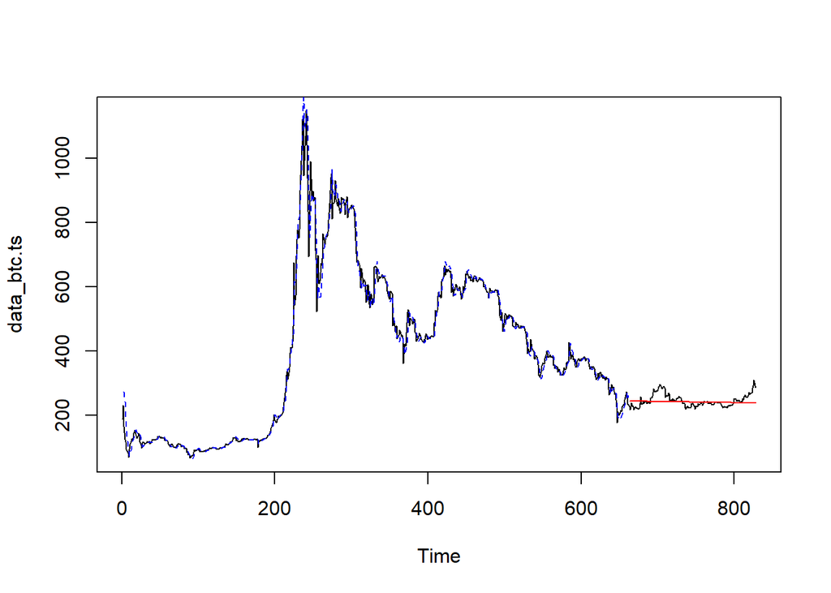

```r
plot(data_btc.ts)
lines(des.1$fitted[,1], lty=2, col="blue")
lines(ramalandes1$mean, col="red")
```

```r
#akurasi train
ssedes.train1<-des.1$SSE
msedes.train1<-ssedes.train1/length(train_data.ts)
sisaandes1<-ramalandes1$residuals
head(sisaandes1)
```

```
## Time Series:
## Start = 1
## End = 6
## Frequency = 1
## [1]       NA       NA -107.500 -125.600  -89.890  -79.146
```

```r
mapedes.train1 <- sum(abs(sisaandes1[3:length(train_data.ts)]/train.ts[3:length(train_data.ts)])
                      *100)/length(train.ts)

akurasides.1 <- matrix(c(ssedes.train1,msedes.train1,mapedes.train1))
row.names(akurasides.1)<- c("SSE", "MSE", "MAPE")
colnames(akurasides.1) <- c("Akurasi train DES lambda 0.5 dan gamma 0.2")
akurasides.1
```

```
##      Akurasi train DES lambda 0.5 dan gamma 0.2
## SSE                                763836.18426
## MSE                                  1153.83109
## MAPE                                    4.73867
```

```r
#akurasi testing
selisihdes1<-ramalandes1$mean-test_data$price
selisihdes1
```

```
## Time Series:
## Start = 663
## End = 828
## Frequency = 1
##   [1]  17.0878977  26.6425339  17.1253702   5.9454064  16.4947427  16.6872789
##   [7]  26.6100152  20.8641514  15.9839877  20.4088239  23.0672602  23.1236964
##  [13]  23.6794327  21.2853689   7.3148052 -14.4073586   8.7025777   9.4350139
##  [19]  -0.6364498   6.7131864   3.0569227  -0.9186411  -1.4337048   7.2571314
##  [25]   4.6675677   3.9570039   5.4308402   6.5520764  -9.8988873 -10.9510511
##  [31] -16.2002148 -28.8451786 -38.9773423 -29.4848061 -32.4625698 -29.8436336
##  [37] -33.5572973 -32.1778611 -46.2535248 -48.2843886 -53.6374523 -51.7094161
##  [43] -42.1610798 -39.2737436 -43.2887073 -48.3584711 -42.4724348 -13.4182986
##  [49] -17.8274623 -18.9600261 -17.7731898 -25.9887536 -24.1701173  -3.7040811
##  [55]  -4.4307448  -5.9798086  -4.9481723 -10.6537361  -0.4531998  -5.3236636
##  [61]  -1.8960273  -5.0963911 -10.8331548 -12.1554186 -11.7670823 -18.6265461
```

[output cut: 17 more lines]

```r
SSEtestingdes1<-sum(selisihdes1^2)
MSEtestingdes1<-SSEtestingdes1/length(test_data$price)
MAPEtestingdes1<-sum(abs(selisihdes1/test_data$price)*100)/length(test_data$price)
akurasitestingdes = matrix(c(SSEtestingdes1,
                               MSEtestingdes1,
                               MAPEtestingdes1),
                             nrow = 3, ncol = 1)

row.names(akurasitestingdes) = c("SSE", "MSE", "MAPE")
colnames(akurasitestingdes) = c("Akurasi test DES lambda 0.5 dan gamma 0.2")

# Tampilkan hasil
akurasitestingdes
```

```
##      Akurasi test DES lambda 0.5 dan gamma 0.2
## SSE                                67303.69594
## MSE                                  405.44395
## MAPE                                   5.80501
```

```r
# Akurasi SMA m=7

akurasi_train.sma7
```

```
##      Akurasi train sma m = 7
## SSE             1.489917e+06
## MSE             2.274683e+03
## MAPE            6.415937e+00
```

```r
akurasi_test.sma7
```

```
##      Akurasi test sma m = 7
## SSE            64226.141760
## MSE              386.904468
## MAPE               6.520457
```

```r
#SES dengan lambda 0.7
accuracy(ramalan3, test_data$price)
```

```
##                     ME     RMSE      MAE        MPE     MAPE     MASE      ACF1
## Training set 0.1033947 30.93536 15.46566 -0.2206387 3.901717 1.047826 0.2794223
## Test set     9.6764282 21.73487 15.15982  3.3810858 5.831180 1.027105        NA
```

```r
#Akurasi DES lambda 0.5 dan gamma 0.2
akurasides.1
```

```
##      Akurasi train DES lambda 0.5 dan gamma 0.2
## SSE                                763836.18426
## MSE                                  1153.83109
## MAPE                                    4.73867
```

```r
akurasitestingdes
```

```
##      Akurasi test DES lambda 0.5 dan gamma 0.2
## SSE                                67303.69594
## MSE                                  405.44395
## MAPE                                   5.80501
```